# STAT 184 Homework Exercises

DataComputing Chapters 7

Ziyuan Ye

## Assigned Exercises

- DC Chapter 7 Exercises: 7.1, 7.3, 7.5, 7.6, 7.7, 7.8

## Front Matter

```r
# clean up workspace environment
rm(list = ls())

# all packages used for the assignment
library(mosaic)
library(tidyverse)
library(dcData)
library(dplyr)
library(esquisse)
library(ggplot2)
```

## Chapter 7 Exercises

### Problem 7.1

1. transformation function
2. transformation function
3. reduction function
4. transformation function
5. transformation function
6. reduction function
7. transformation function
8. reduction function

### Problem 7.3

```r
Minneapolis2013=(Minneapolis2013)
Minneapolis2013 %>%
  summarise(count = n())
```

```
##   count
## 1 80101
```

```r
Minneapolis2013 %>%
  group_by(Second) %>%
  summarise(count = n())%>%
  arrange(desc(count))%>%
  top_n(5)
```

```
## # A tibble: 5 × 2
##   Second             count
##   <chr>              <int>
## 1 BETSY HODGES       14399
## 2 DON SAMUELS        14170
## 3 MARK ANDREW        12757
## 4 undervote          10598
## 5 JACKIE CHERRYHOMES  6470
```

```r
Minneapolis2013 %>%
  group_by(First) %>%
  summarise(count = n()) %>%
  filter(First=="undervote")
```

```
## # A tibble: 1 × 2
##   First     count
##   <chr>     <int>
## 1 undervote   834
```

```r
Minneapolis2013 %>%
  group_by(Second) %>%
  summarise(count = n()) %>%
  filter(Second=="undervote")
```

```
## # A tibble: 1 × 2
##   Second    count
##   <chr>     <int>
## 1 undervote 10598
```

```r
Minneapolis2013 %>%
  group_by(Third) %>%
  summarise(count = n()) %>%
  filter(Third=="undervote")
```

```
## # A tibble: 1 × 2
##   Third     count
##   <chr>     <int>
## 1 undervote 19210
```

```r
Minneapolis2013 %>%
  group_by(First, Second) %>%
  summarise(count = n())%>%
  arrange(desc(count))%>%
  top_n(3)
```

```
## # A tibble: 124 × 3
## # Groups:   First [38]
##    First        Second             count
##    <chr>        <chr>              <int>
##  1 BETSY HODGES MARK ANDREW         8787
##  2 BETSY HODGES DON SAMUELS         8743
##  3 MARK ANDREW  BETSY HODGES        6970
##  4 MARK ANDREW  undervote           3889
##  5 DON SAMUELS  BETSY HODGES        3346
##  6 MARK ANDREW  DON SAMUELS         2880
##  7 BETSY HODGES JACKIE CHERRYHOMES  2563
##  8 DON SAMUELS  MARK ANDREW         1424
##  9 CAM WINTON   undervote           1349
## 10 CAM WINTON   BETSY HODGES        1043
## # … with 114 more rows
```

```r
Minneapolis2013 %>%
  group_by(Precinct) %>%
  summarise(count = n())%>%
  arrange(desc(count))%>%
  top_n(3)
```

```
## # A tibble: 3 × 2
##   Precinct count
##   <chr>    <int>
## 1 P-06      9711
## 2 P-02      9551
## 3 P-08      9430
```

P-06, 9711 ballots

### Problem 7.5

```r
VoterData_A <-
  Minneapolis2013 %>%
  group_by(First, Second)
```

The voterData has been modified by First and Second, case is voter

```r
VoterData_B <-
 Minneapolis2013 %>%
  summarise( total = n() )
```

It represent the total number of case in VoterData_B

```r
VoterData_C <-
  Minneapolis2013 %>%
  group_by(First, Second) %>%
  summarise( total = n() )
```

It represent the total number of First and Second cases correspondingly

4. After summarise( total = n() ) %>%, the result is an int, there is no First or Second.

### Problem 7.6:

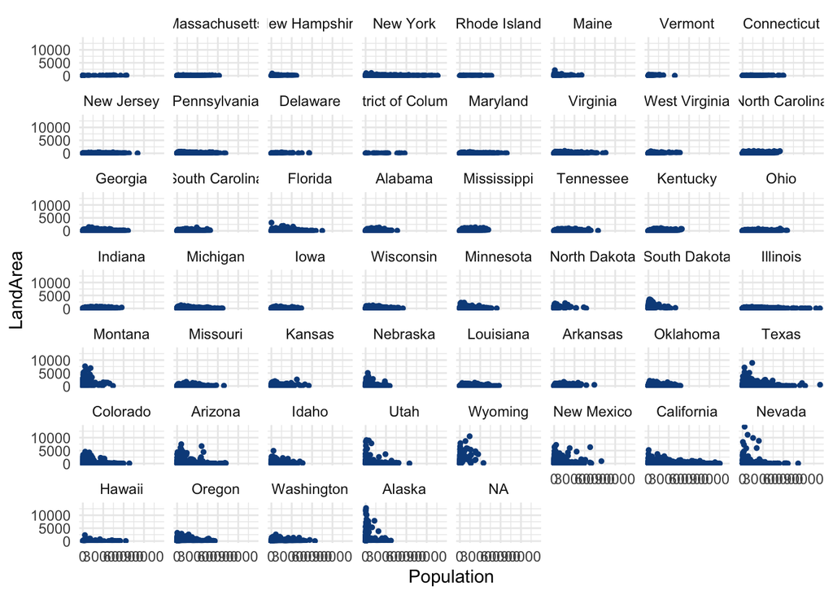

```r
ZipGeography = (ZipGeography)
ZipGeography %>%
 filter(!(Timezone %in% " ") | is.na(Timezone)) %>%
 ggplot() +
 aes(x = Population, y = LandArea) +
 geom_point(size = 1L, colour = "#0c4c8a") +
 theme_minimal() +
 facet_wrap(vars(State))
```

```r
new_ZipGeography <-
  ZipGeography %>%
  group_by(State) %>%
  summarise(sum_population = sum(Population, na.rm = TRUE) )
```

```
## Mapping API still under development and may change in future releases.
```

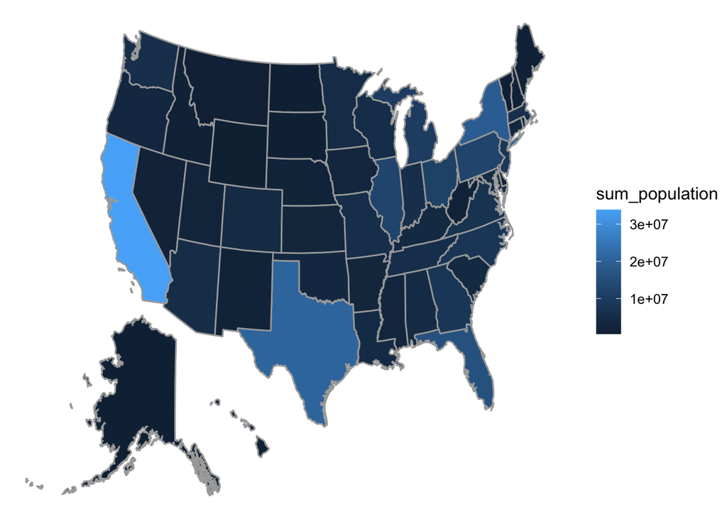

```r
mUSMap(new_ZipGeography, key = "State", fill = "sum_population")
```

```r
noval_ZipGeography <-
  ZipGeography %>%
  group_by(State) %>%
  summarise(unit_area_state = (sum(LandArea, na.rm = TRUE) /sum(Population, na.rm = TRUE)) )
```

```
## Mapping API still under development and may change in future releases.
```

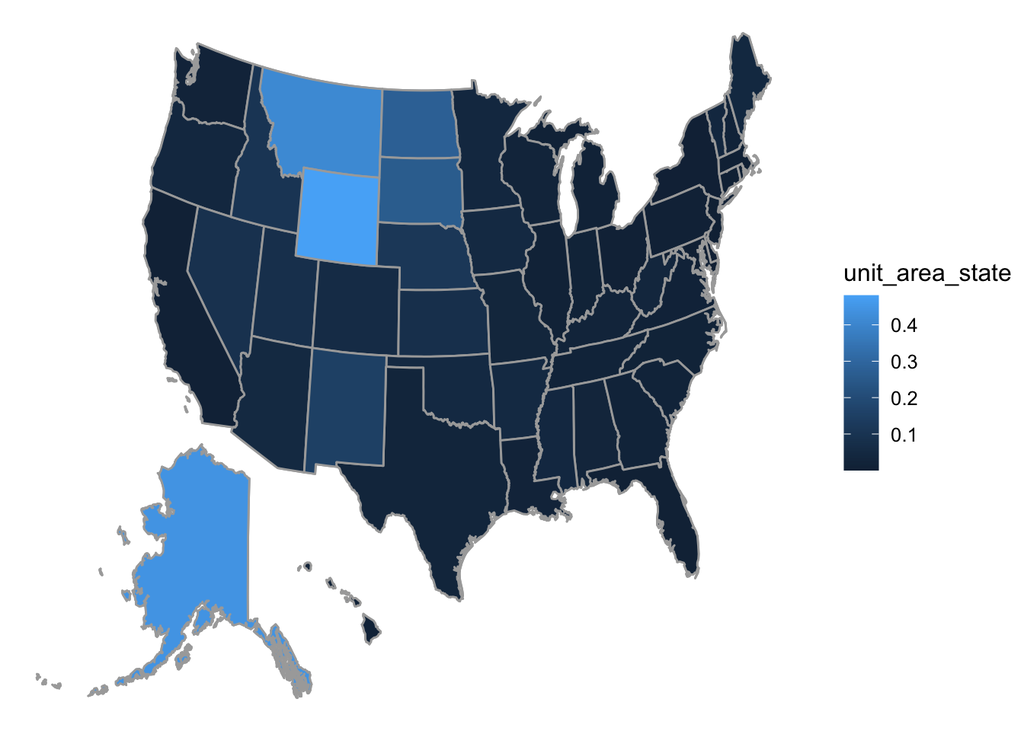

```r
mUSMap(noval_ZipGeography, key = "State", fill = "unit_area_state")
```

### Problem 7.7:

1. number and average age of female and male patient
2. for each diagnosis result, number of patient in it and average age
3. diagnosis: for female and male, each diagnosis result, number of patient in it and average age
4. diagnosis: for eacha ge of patient,each diagnosis result, number of patient in it and average age
5. number of each age patient, average age

### Problem 7.8:

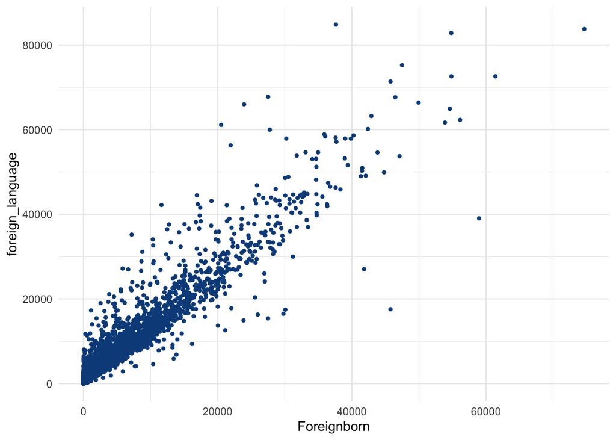

```r
ZipDemography=(ZipDemography)
ggplot(ZipDemography) +
 aes(x = Foreignborn, y = SpeakalanguageotherthanEnglishathome5yearsandover) +
 geom_point(size = 1L, colour = "#0c4c8a") +
 labs(y = "foreign_language") +
 theme_minimal()
```

2. Set Bachelorsdegreeorhigher be the y-axis, total population be the x-axis. The coefficient of slope is the fraction of people who has bachelors degree or higher, then add state as facet.